# Tarea 1 - Big Data

Shanthal Chavarría

2021-07-14

# 1. **[10 puntos]** Con en la conferencia Desde la Estadística hasta la Ciencia de Datos, pasando porcel concepto de Big Data, cuyo vídeo está en el Aula Virtual, explique los siguientes conceptos:

1. Computación en la Nube.
2. “Big Data” y el significado de las 7V’s.
3. Explique con detalle los conceptos, Minería de Datos, “Machine Lerning”, Ciencia de Datos e Ingeniería de Datos y explique cuáles son las diferencias entre dichos conceptos.

# 2. **[15 puntos]** Utilizando las funciones del archivo `funciones.R` disponible en el aula virtual realice lo siguiente.

## a) Analice una a una las funciones del archivo e identifique factores que puedan aumentar su tiempo de ejecución.

```r
library(dtplyr)
# Numeros primos
es_primo <- function(x) {
    divisores <- 2:ceiling(sqrt(x))
    for (i in seq_along(divisores)) {
        if (x%%divisores[i] == 0) {
            return(FALSE)
        }
    }
    return(TRUE)
}
```

Aumenta su tiempo debido al loop que recorre una a uno los indices de x.

```r
# Precision global
precision_global <- function(real, ref) {
    contador <- 0
    for (i in seq_along(real)) {
        if (real[i] == ref[i]) {
            contador <- contador + 1
        }
    }

    resultado <- contador/length(real)
    return(resultado)
}
```

```r
# Detectar na en data.frame
tiene_na <- function(x) {
    for (i in 1:nrow(x)) {
        for (j in 1:ncol(x)) {
            if (is.na(x[i, j])) {
                return(TRUE)
            }
        }
    }

    return(FALSE)
}
```

Son dos for anidados que van verificando por fila cada entrada si es NA. Esto no debería ser necesario ya que R es vectorial y no hay necesidad de dos loops.

## b) Cree una versión alternativa a cada una de las funciones en la que aplique los cambios que considere necesarios y explique cada uno de ellos.

```r
es_primo1 <- function(x) {

    divisores <- 2:ceiling(sqrt(x))
    all(x%%divisores != 0)

}
es_primo1(8)
```

```
[1] FALSE
```

```r
es_primo1(7)
```

```
[1] TRUE
```

Elimino el loop y verifico que si hay un divisor algún divisor entero me de FALSE.

```r
precision_global1 <- function(real, ref) {
    contador <- sum(ref == real, na.rm = TRUE)

    resultado <- contador/length(real)
    return(resultado)
}
```

ELimino el loop, despues cuento en cuantos indices se parecen ambos vectores inmediatamente sin necesidad de remplazarlo como en la otra función. Finalmente lo divido entre el total de entradas.

```r
tiene_na1 <- function(x) {
    any(is.na(x) == TRUE)
}

color <- c("azul", "blanco", "rojo", "verde")
nota <- c(1, 4, NA, 6)
tabla <- data.frame(color, nota)
tabla
```

| color | nota |
| --- | --- |
| azul | 1 |
| blanco | 4 |
| rojo | NA |
| verde | 6 |

```r
tiene_na1(tabla)
```

```
[1] TRUE
```

Revisa si algún valor de la tabla es NA con is.na que recorre sin necesidad de for cada entrada y retorna True si existe.

## c) Utilizando la función `mark` del paquete `bench` compare el rendimiento de las funciones originales con su versión modificada.

```r
library(bench)

mark(`ciclo for` = es_primo(1789), vectorizado = es_primo1(1789), relative = T)
```

```
# A tibble: 2 x 6
  expression    min median `itr/sec` mem_alloc `gc/sec`
  <bch:expr>  <dbl>  <dbl>     <dbl>     <dbl>    <dbl>
1 ciclo for    3.66   3.61      1         115.     1
2 vectorizado  1      1         3.56        1      1.19
```

```r
real <- sample(0:1, 10000, T)
ref <- sample(0:1, 10000, T)

mark(`ciclo for` = precision_global(real, ref), vectorizado = precision_global1(real,
    ref), relative = T)
```

```
# A tibble: 2 x 6
  expression    min median `itr/sec` mem_alloc `gc/sec`
  <bch:expr>  <dbl>  <dbl>     <dbl>     <dbl>    <dbl>
1 ciclo for    13.7   9.67      1         1.06      NaN
2 vectorizado   1     1         9.70      1         Inf
```

```r
mark(`ciclo for` = tiene_na(iris), vectorizado = tiene_na1(iris), relative = T)
```

```
# A tibble: 2 x 6
  expression    min median `itr/sec` mem_alloc `gc/sec`
  <bch:expr>  <dbl>  <dbl>     <dbl>     <dbl>    <dbl>
1 ciclo for    377.   346.        1       3.61     1.88
2 vectorizado    1      1       333.      1        1
```

# 3. [30 puntos] Diseñe un script que permita aplicar LOOCV (validación cruzada dejando uno fuerza) para un modelo de árboles con sus parámetros por defecto, en esta debe aplicar los conceptos de programación vistos en la clase, así como señalar los puntos en donde considera fue oportuno utilizarlos, debe adjuntar una demostración del funcionamiento de su código con la tabla de datos `iris`.

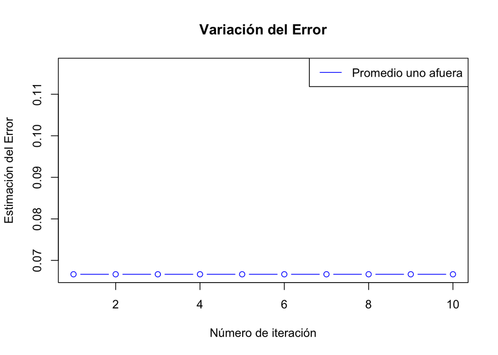

```r
library(traineR)
datos <- read.csv("Datos_Tarea/iris.csv", sep = ";", dec = ".", header = T, stringsAsFactors = T)
## Vamos a generar el modelo dejando un dato para testing.
v.error.loo <- rep(0, 10)
n <- dim(datos)[1]
# Se hace 10 veces para verificar que no varía
for (i in 1:10) {
    errori <- 0
    # Este ciclo es que hace 'leave one out' (dejar uno afuera)
    for (j in 1:n) {
        muestra <- j
        ttesting <- datos[muestra, ]
        taprendizaje <- datos[-muestra, ]
        modelo <- train.rpart(tipo ~ ., data = taprendizaje)
        prediccion <- predict(modelo, ttesting, type = "class")
        if (prediccion$prediction != ttesting$tipo) {
            errori <- errori + 1
        }
    }
    v.error.loo[i] <- errori/n
}

plot(v.error.loo, col = "blue", type = "b", ylim = c(min(v.error.loo), max(v.error.loo) +
    0.05), main = "Variación del Error", xlab = "Número de iteración", ylab = "Estimación del Error")
legend("topright", legend = c("Promedio uno afuera"), col = c("blue"), lty = 1, lwd = 1)
```

# 4. **[20 puntos]** En este ejercicio empleamos la tabla `CensusIncome` que contiene información de individuos residentes en Estados Unidos. Entre la información contenida se encuentra la edad, educación, ocupación, género, horas laboradas a la semana y país nativo.

```r
library(readr)

datos <- read.table("Datos_Tarea/CensusIncome.csv", sep = ",", header = T)
```

Con estos datos efectúe lo siguiente:

## a) Usando el paquete `dplyr` cree un resumen que contenga el mínimo, máximo, mediana, media y desviación estándar de la horas laboradas a la semana, esto agrupando los datos por sexo, raza y nivel educativo.

```r
library(dplyr)

datos %>% group_by(race, sex, education) %>% summarise(Minimo = min(hours.per.week),
    Maximo = max(hours.per.week), Promedio = mean(hours.per.week), Mediana = median(hours.per.week),
    Desv_Estand = sd(hours.per.week))
```

| race | sex | education | Minimo | Maximo | Promedio | Mediana | Desv_Estand |
| --- | --- | --- | --- | --- | --- | --- | --- |
| Amer-Indian-Eskimo | Female | 10th | 20 | 45 | 34.37500 | 40.0 | 9.797048 |
| Amer-Indian-Eskimo | Female | 11th | 15 | 40 | 24.16667 | 22.5 | 9.703951 |
| Amer-Indian-Eskimo | Female | 1st-4th | 20 | 35 | 27.50000 | 27.5 | 10.606602 |
| Amer-Indian-Eskimo | Female | 7th-8th | 20 | 40 | 33.33333 | 40.0 | 11.547005 |
| Amer-Indian-Eskimo | Female | 9th | 15 | 20 | 17.50000 | 17.5 | 3.535534 |
| Amer-Indian-Eskimo | Female | Assoc-acdm | 40 | 46 | 40.75000 | 40.0 | 2.121320 |
| Amer-Indian-Eskimo | Female | Assoc-voc | 24 | 60 | 39.26667 | 40.0 | 7.657552 |
| Amer-Indian-Eskimo | Female | Bachelors | 25 | 48 | 39.90909 | 40.0 | 5.539938 |
| Amer-Indian-Eskimo | Female | Doctorate | 40 | 60 | 50.00000 | 50.0 | 14.142136 |
| Amer-Indian-Eskimo | Female | HS-grad | 8 | 78 | 38.58929 | 40.0 | 10.560263 |

[output cut: 65 more lines]

## b) Repita el ejercicio anterior utilizando el paquete dtplyr.

```r
library(dtplyr)

# cambio de tipo de datos

datos_dt <- lazy_dt(datos)

datos_dt %>% group_by(race, sex, education) %>% summarise(Minimo = min(hours.per.week),
    Maximo = max(hours.per.week), Promedio = mean(hours.per.week), Mediana = median(hours.per.week),
    Desv_Estand = sd(hours.per.week))
```

```
Source: local data table [153 x 8]
Groups: race, sex
Call:   `_DT1`[, .(Minimo = min(hours.per.week), Maximo = max(hours.per.week),
    Promedio = mean(hours.per.week), Mediana = median(hours.per.week),
    Desv_Estand = sd(hours.per.week)), keyby = .(race, sex, education)]

  race               sex    education Minimo Maximo Promedio Mediana Desv_Estand
  <chr>              <chr>  <chr>      <int>  <int>    <dbl>   <dbl>       <dbl>
1 Amer-Indian-Eskimo Female 10th          20     45     34.4    40          9.80
2 Amer-Indian-Eskimo Female 11th          15     40     24.2    22.5        9.70
3 Amer-Indian-Eskimo Female 1st-4th       20     35     27.5    27.5       10.6
4 Amer-Indian-Eskimo Female 7th-8th       20     40     33.3    40         11.5
5 Amer-Indian-Eskimo Female 9th           15     20     17.5    17.5        3.54
6 Amer-Indian-Eskimo Female Assoc-ac…     40     46     40.8    40          2.12
# … with 147 more rows

# Use as.data.table()/as.data.frame()/as_tibble() to access results
```

## c) Utilizando la función mark del paquete bench eval´ue el rendimiento de ambos paquetes

```r
mark(data.table = {
    datos_dt %>% group_by(race, sex, education) %>% summarise(Minimo = min(hours.per.week),
        Maximo = max(hours.per.week), Promedio = mean(hours.per.week), Mediana = median(hours.per.week),
        Desv_Estand = sd(hours.per.week)) %>% as_tibble()
}, dplyr = {
    datos %>% group_by(race, sex, education) %>% summarise(Minimo = min(hours.per.week),
        Maximo = max(hours.per.week), Promedio = mean(hours.per.week), Mediana = median(hours.per.week),
        Desv_Estand = sd(hours.per.week))
}, check = F)
```

```
# A tibble: 2 x 6
  expression      min   median `itr/sec` mem_alloc `gc/sec`
  <bch:expr> <bch:tm> <bch:tm>     <dbl> <bch:byt>    <dbl>
1 data.table   5.91ms   6.46ms     150.     1.41MB    11.2
2 dplyr       13.38ms  15.14ms      65.2    1.88MB     6.74
```

# 5. [20 puntos] Para este ejercicio vamos a hacer uso de la tabla de datos `Creditcard`, la cual contiene información de las transacciones de los clientes en la cartera de crédito del banco. Por temas de confidencialidad el banco no nos proporciona las variables originales ni nos brinda información detallada de los datos, sino que pone a disposición una tabla donde la mayoría de las columnas son transformaciones de las variables originales, esto con el fin de proteger la información sensible.

La tabla de datos contiene 284 807 transacciones y 31 columnas que las describen. Seguidamente se explican las variables que conforman la tabla.

- `Time`: Cantidad de segundos transcurridos entre la primera transacción y la transacción actual.
- `V1, ..., V28`: Transformaciones de las variables numéricas originales que describen cada transacción
- `Amount`: Monto por el que se registra la transacción.
- `Class`: Indica si la transacción corresponde a una transacción fraudulenta o no.

```r
datos <- read.table("Datos_Tarea/creditcard.csv", sep = ",", dec = ".", header = T)

datos$Class <- as.factor(datos$Class)
```

Luego, de la forma más eficiente posible, efectue lo siguiente:

## a) Calcule la media de la variable `Amount` agrupado por la variable `Class` y presente los resultados en un data.frame.

```r
library(dtplyr)
library(data.table)
library(dplyr)

# convertimos a tipo dt
datos_dt <- lazy_dt(datos)

datos_dt %>% group_by(Class) %>% summarise_each(funs(mean))
```

```
Source: local data table [2 x 31]
Call:   `_DT2`[, .(Time = mean(Time), V1 = mean(V1), V2 = mean(V2), V3 = mean(V3),
    V4 = mean(V4), V5 = mean(V5), V6 = mean(V6), V7 = mean(V7),
    V8 = mean(V8), V9 = mean(V9), V10 = mean(V10), V11 = mean(V11),
    V12 = mean(V12), V13 = mean(V13), V14 = mean(V14), V15 = mean(V15),
    V16 = mean(V16), V17 = mean(V17), V18 = mean(V18), V19 = mean(V19),
    V20 = mean(V20), V21 = mean(V21), V22 = mean(V22), V23 = mean(V23),
    V24 = mean(V24), V25 = mean(V25), V26 = mean(V26), V27 = mean(V27),
    V28 = mean(V28), Amount = mean(Amount)), keyby = .(Class)]

  Class   Time       V1       V2      V3       V4       V5       V6       V7
  <fct>  <dbl>    <dbl>    <dbl>   <dbl>    <dbl>    <dbl>    <dbl>    <dbl>
1 0     94838.  0.00826 -0.00627  0.0122 -0.00786  0.00545  0.00242  0.00964
2 1     80747. -4.77     3.62    -7.03    4.54    -3.15    -1.40    -5.57
# … with 22 more variables: V8 <dbl>, V9 <dbl>, V10 <dbl>, V11 <dbl>,
#   V12 <dbl>, V13 <dbl>, V14 <dbl>, V15 <dbl>, V16 <dbl>, V17 <dbl>,
#   V18 <dbl>, V19 <dbl>, V20 <dbl>, V21 <dbl>, V22 <dbl>, V23 <dbl>,
#   V24 <dbl>, V25 <dbl>, V26 <dbl>, V27 <dbl>, V28 <dbl>, Amount <dbl>

# Use as.data.table()/as.data.frame()/as_tibble() to access results
```

## b) Suponga que quiere encontrar el mejor modelo para predecir la variable `Class`, para esto genere 3 Validaciones Cruzadas con 3 grupos para los métodos `Árboles`, `Regresión` y `Bayes`, puede utilizar los parámetros por defecto.

```r
library(traineR)
library(caret)

numero.filas <- nrow(datos)
cantidad.validacion.cruzada <- 3
cantidad.grupos <- 3


MCs.bayes <- matrix(c(0, 0, 0, 0), nrow = 2)
MCs.arbol <- matrix(c(0, 0, 0, 0), nrow = 2)
MCs.glm <- matrix(c(0, 0, 0, 0), nrow = 2)




for (i in 1:cantidad.validacion.cruzada) {
    grupos <- createFolds(1:numero.filas, cantidad.grupos)

    MC.bayes <- matrix(c(0, 0, 0, 0), nrow = 2)
    MC.arbol <- matrix(c(0, 0, 0, 0), nrow = 2)
    MC.glm <- matrix(c(0, 0, 0, 0), nrow = 2)



    for (k in 1:cantidad.grupos) {
        muestra <- grupos[[k]]

        ttesting <- datos[muestra, ]
        ttraining <- datos[-muestra, ]

        # modelos
        modelo <- train.bayes(Class ~ ., data = ttraining)
        prediccion <- predict(modelo, ttesting)
        MC <- confusion.matrix(ttesting, prediccion)
        MC.bayes <- MC.bayes + MC

        modelo = train.rpart(Class ~ ., data = ttraining)
        prediccion <- predict(modelo, ttesting)
        MC <- confusion.matrix(ttesting, prediccion)
        MC.arbol <- MC.arbol + MC

        modelo <- train.glm(Class ~ ., data = ttraining)
        prediccion <- predict(modelo, ttesting)
        MC <- confusion.matrix(ttesting, prediccion)
        MC.glm <- MC.glm + MC


    }



    MCs.bayes <- MCs.bayes + MC.bayes
    MCs.arbol <- MCs.arbol + MC.arbol
    MCs.glm <- MCs.glm + MC.glm

}

precision <- function(mc, clase) {

    indices = general.indexes(mc = mc)

    return(indices)


}


bayesPrecision <- precision(MCs.bayes/3)
arbolPrecision <- precision(MCs.arbol/3)
glmPrecision <- precision(MCs.glm/3)

bayesPrecision
```

```
Confusion Matrix:
    prediction
real      0      1
   0 278097   6218
   1     84    408

Overall Accuracy: 0.9779
Overall Error:    0.0221

Category Accuracy:

            0            1
     0.978130     0.829268
```

```r
arbolPrecision
```

```
Confusion Matrix:
    prediction
real           0           1
   0 284271.0000     44.0000
   1    116.3333    375.6667

Overall Accuracy: 0.9994
Overall Error:    0.0006

Category Accuracy:

            0            1
     0.999845     0.763550
```

```r
glmPrecision
```

```
Confusion Matrix:
    prediction
real            0            1
   0 284268.33333     46.66667
   1    186.66667    305.33333

Overall Accuracy: 0.9992
Overall Error:    0.0008

Category Accuracy:

            0            1
     0.999836     0.620596
```